# AIML_ML_Project_full_code_notebook

## now, lets visualize the decision tree for the model2

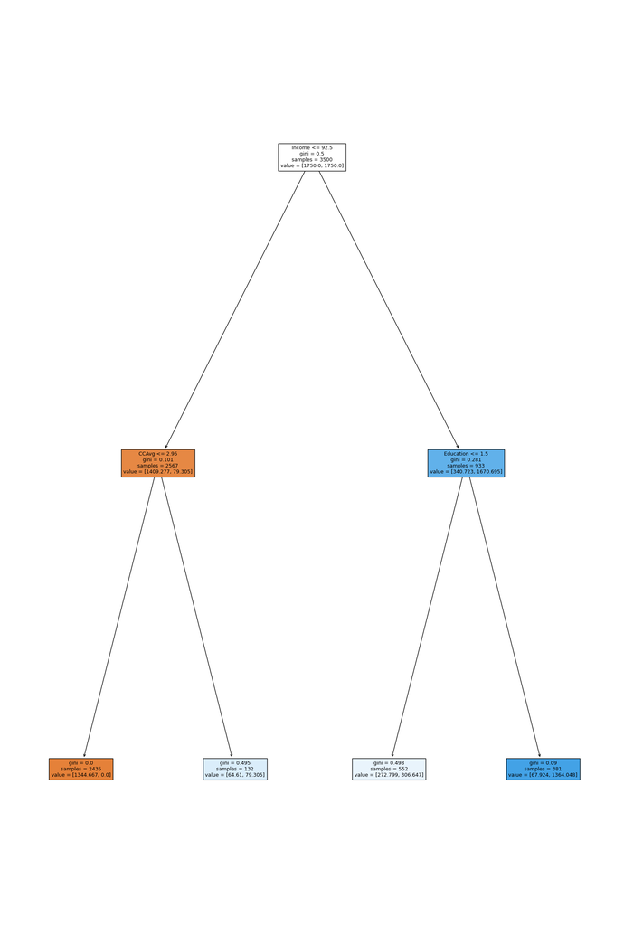

```python
visualize_tree(model2, feature_names)
```

```python
# Text report showing the rules of a decision tree -
print(tree.export_text(model2, feature_names=feature_names, show_weights=True))
```

```
|--- Income <= 92.50
|   |--- CCAvg <= 2.95
|   |   |--- weights: [1344.67, 0.00] class: 0
|   |--- CCAvg >  2.95
|   |   |--- weights: [64.61, 79.31] class: 1
|--- Income >  92.50
|   |--- Education <= 1.50
|   |   |--- weights: [272.80, 306.65] class: 1
|   |--- Education >  1.50
|   |   |--- weights: [67.92, 1364.05] class: 1
```

```python
importances = model2.feature_importances_
importances
```

```
array([0.        , 0.        , 0.82007181, 0.        , 0.        ,
       0.06262835, 0.11729984, 0.        , 0.        , 0.        ,
       0.        , 0.        ])
```

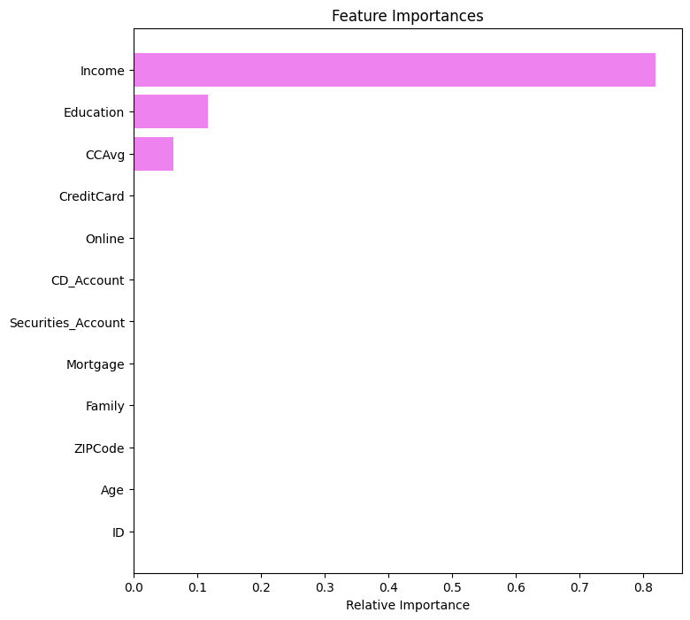

```python
feature_importance_visualize(model2, feature_names)
```

- In the pre-pruned decision tree, income is the important feature.

### Decision Tree (Post pruning)

- Cost complexity pruning provides another option to control the size of a tree.
- In `DecisionTreeClassifier`, this pruning technique is parameterized by the cost complexity parameter, `ccp_alpha`.
- Greater values of `ccp_alpha` increase the number of nodes pruned.
- Here we only show the effect of `ccp_alpha` on regularizing the trees and how to choose the optimal `ccp_alpha` value.

**Total impurity of leaves vs effective alphas of pruned tree**

Minimal cost complexity pruning recursively finds the node with the "weakest link". The weakest link is characterized by an effective alpha, where the nodes with the smallest effective alpha are pruned first. To get an idea of what values of `ccp_alpha` could be appropriate, scikit-learn provides `DecisionTreeClassifier.cost_complexity_pruning_path` that returns the effective alphas and the corresponding total leaf impurities at each step of the pruning process. As alpha increases, more of the tree is pruned, which increases the total impurity of its leaves.

```python
clf = DecisionTreeClassifier(random_state=1, class_weight="balanced")
path = clf.cost_complexity_pruning_path(X_train, y_train)
ccp_alphas, impurities = abs(path.ccp_alphas), path.impurities
```

```python
pd.DataFrame(path)
```

|  | ccp_alphas | impurities |
| --- | --- | --- |
| 0 | 0.000000e+00 | -9.128291e-15 |
| 1 | 3.853725e-19 | -9.127906e-15 |
| 2 | 4.729571e-19 | -9.127433e-15 |
| 3 | 4.729571e-19 | -9.126960e-15 |
| 4 | 4.729571e-19 | -9.126487e-15 |
| 5 | 1.051016e-18 | -9.125436e-15 |
| 6 | 1.257806e-17 | -9.112858e-15 |
| 7 | 1.545500e-04 | 3.090999e-04 |
| 8 | 1.570652e-04 | 6.232303e-04 |
| 9 | 1.574681e-04 | 9.381666e-04 |
| 10 | 2.857143e-04 | 1.509595e-03 |
| 11 | 3.083987e-04 | 2.126393e-03 |
| 12 | 3.104109e-04 | 2.747214e-03 |
| 13 | 3.130853e-04 | 3.373385e-03 |
| 14 | 3.604006e-04 | 4.814987e-03 |
| 15 | 3.797005e-04 | 6.333789e-03 |
| 16 | 4.354786e-04 | 7.204746e-03 |
| 17 | 5.342287e-04 | 7.738975e-03 |
| 18 | 5.375794e-04 | 8.276554e-03 |
| 19 | 5.880239e-04 | 9.452602e-03 |
| 20 | 7.208073e-04 | 1.017341e-02 |
| 21 | 7.410410e-04 | 1.091445e-02 |
| 22 | 7.689471e-04 | 1.168340e-02 |
| 23 | 9.657103e-04 | 1.458053e-02 |
| 24 | 1.044599e-03 | 1.562513e-02 |
| 25 | 1.147734e-03 | 1.677286e-02 |
| 26 | 1.343845e-03 | 1.811671e-02 |
| 27 | 1.416204e-03 | 1.953291e-02 |
| 28 | 1.693744e-03 | 2.292040e-02 |
| 29 | 1.981730e-03 | 2.688386e-02 |
| 30 | 2.150414e-03 | 2.903427e-02 |
| 31 | 2.375809e-03 | 3.141008e-02 |
| 32 | 3.344493e-03 | 3.475457e-02 |
| 33 | 3.602932e-03 | 4.196044e-02 |
| 34 | 3.729690e-03 | 4.569013e-02 |
| 35 | 4.920880e-03 | 5.061101e-02 |
| 36 | 1.007808e-02 | 7.076717e-02 |
| 37 | 2.255792e-02 | 9.332509e-02 |
| 38 | 5.564782e-02 | 2.046207e-01 |
| 39 | 2.953793e-01 | 5.000000e-01 |

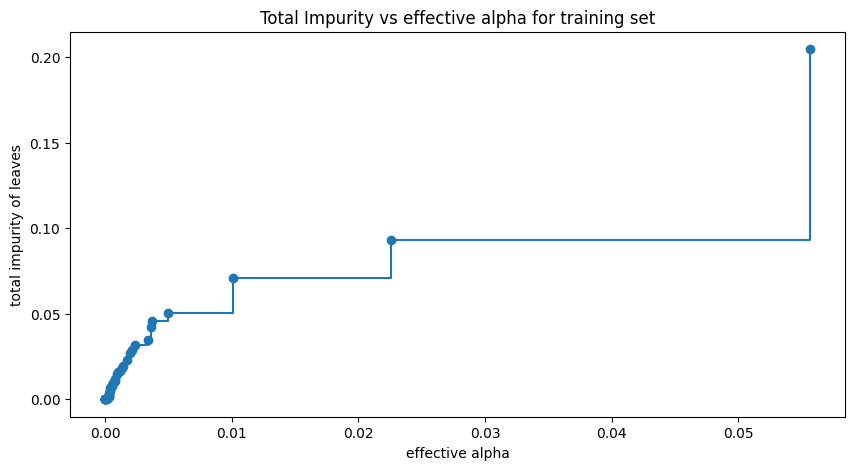

```python
fig, ax = plt.subplots(figsize=(10, 5))
ax.plot(ccp_alphas[:-1], impurities[:-1], marker="o", drawstyle="steps-post")
ax.set_xlabel("effective alpha")
ax.set_ylabel("total impurity of leaves")
ax.set_title("Total Impurity vs effective alpha for training set")
plt.show()
```

Next, we train a decision tree using the effective alphas. The last value in `ccp_alphas` is the alpha value that prunes the whole tree, leaving the tree, `clfs[-1]`, with one node.

```python
clfs = []
for ccp_alpha in ccp_alphas:
    clf = DecisionTreeClassifier(
        random_state=1, ccp_alpha=ccp_alpha, class_weight="balanced"
    )
    clf.fit(X_train, y_train)
    clfs.append(clf)
print(
    "Number of nodes in the last tree is: {} with ccp_alpha: {}".format(
        clfs[-1].tree_.node_count, ccp_alphas[-1]
    )
)
```

```
Number of nodes in the last tree is: 1 with ccp_alpha: 0.2953792759992318
```

For the remainder, we remove the last element in `clfs` and `ccp_alphas`, because it is the trivial tree with only one node. Here we show that the number of nodes and tree depth decreases as alpha increases.

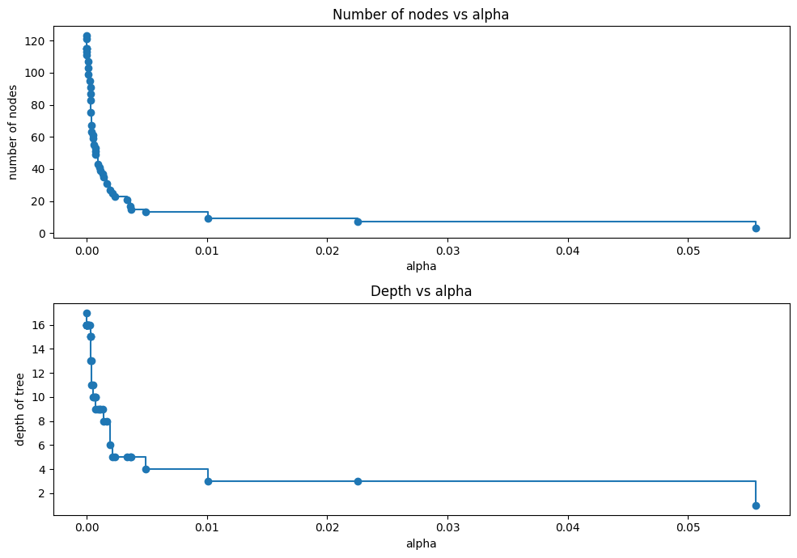

```python
clfs = clfs[:-1]
ccp_alphas = ccp_alphas[:-1]

node_counts = [clf.tree_.node_count for clf in clfs]
depth = [clf.tree_.max_depth for clf in clfs]
fig, ax = plt.subplots(2, 1, figsize=(10, 7))
ax[0].plot(ccp_alphas, node_counts, marker="o", drawstyle="steps-post")
ax[0].set_xlabel("alpha")
ax[0].set_ylabel("number of nodes")
ax[0].set_title("Number of nodes vs alpha")
ax[1].plot(ccp_alphas, depth, marker="o", drawstyle="steps-post")
ax[1].set_xlabel("alpha")
ax[1].set_ylabel("depth of tree")
ax[1].set_title("Depth vs alpha")
fig.tight_layout()
```

```python
recall_train = []
for clf in clfs:
    pred_train = clf.predict(X_train)
    values_train = recall_score(y_train, pred_train)
    recall_train.append(values_train)
```

```python
recall_test = []
for clf in clfs:
    pred_test = clf.predict(X_test)
    values_test = recall_score(y_test, pred_test)
    recall_test.append(values_test)
```

```python
train_scores = [clf.score(X_train, y_train) for clf in clfs]
test_scores = [clf.score(X_test, y_test) for clf in clfs]
```

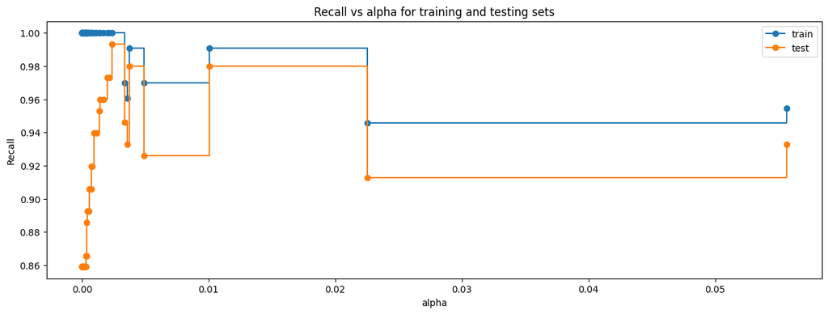

```python
fig, ax = plt.subplots(figsize=(15, 5))
ax.set_xlabel("alpha")
ax.set_ylabel("Recall")
ax.set_title("Recall vs alpha for training and testing sets")
ax.plot(
    ccp_alphas, recall_train, marker="o", label="train", drawstyle="steps-post",
)
ax.plot(ccp_alphas, recall_test, marker="o", label="test", drawstyle="steps-post")
ax.legend()
plt.show()
```

```python
# creating the model where we get highest train and test recall
index_best_model = np.argmax(recall_test)
best_model = clfs[index_best_model]
print(best_model)
```

```
DecisionTreeClassifier(ccp_alpha=0.002375808619774645, class_weight='balanced',
                       random_state=1)
```

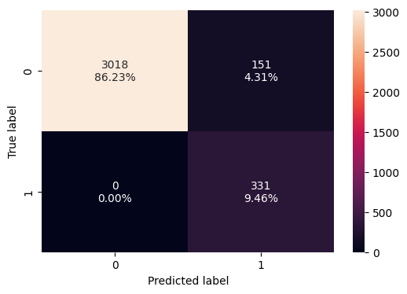

```python
model4 = best_model
confusion_matrix_sklearn(model4, X_train, y_train)
```

```python
decision_tree_post_perf_train = model_performance_classification_sklearn(
    model4, X_train, y_train
)
decision_tree_post_perf_train
```

|  | Accuracy | Recall | Precision | F1 |
| --- | --- | --- | --- | --- |
| 0 | 0.956857 | 1.0 | 0.686722 | 0.814268 |

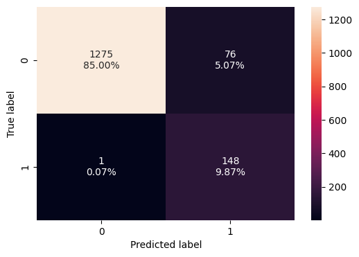

```python
confusion_matrix_sklearn(model4, X_test, y_test)
```

```python
decision_tree_post_test = model_performance_classification_sklearn(
    model4, X_test, y_test
)
decision_tree_post_test
```

|  | Accuracy | Recall | Precision | F1 |
| --- | --- | --- | --- | --- |
| 0 | 0.948667 | 0.993289 | 0.660714 | 0.793566 |

#### Visualize the tree for the post pruning

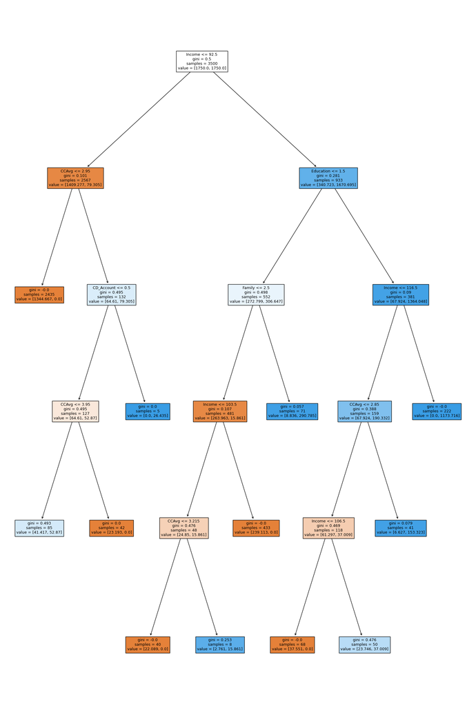

```python
visualize_tree(model4, feature_names)
```

```python
# Text report showing the rules of a decision tree -

print(tree.export_text(model4, feature_names=feature_names, show_weights=True))
```

```
|--- Income <= 92.50
|   |--- CCAvg <= 2.95
|   |   |--- weights: [1344.67, 0.00] class: 0
|   |--- CCAvg >  2.95
|   |   |--- CD_Account <= 0.50
|   |   |   |--- CCAvg <= 3.95
|   |   |   |   |--- weights: [41.42, 52.87] class: 1
|   |   |   |--- CCAvg >  3.95
|   |   |   |   |--- weights: [23.19, 0.00] class: 0
|   |   |--- CD_Account >  0.50
|   |   |   |--- weights: [0.00, 26.44] class: 1
|--- Income >  92.50
|   |--- Education <= 1.50
|   |   |--- Family <= 2.50
|   |   |   |--- Income <= 103.50
|   |   |   |   |--- CCAvg <= 3.21
|   |   |   |   |   |--- weights: [22.09, 0.00] class: 0
|   |   |   |   |--- CCAvg >  3.21
|   |   |   |   |   |--- weights: [2.76, 15.86] class: 1
|   |   |   |--- Income >  103.50
|   |   |   |   |--- weights: [239.11, 0.00] class: 0
|   |   |--- Family >  2.50
|   |   |   |--- weights: [8.84, 290.79] class: 1
|   |--- Education >  1.50
|   |   |--- Income <= 116.50
|   |   |   |--- CCAvg <= 2.85
|   |   |   |   |--- Income <= 106.50
|   |   |   |   |   |--- weights: [37.55, 0.00] class: 0
|   |   |   |   |--- Income >  106.50
|   |   |   |   |   |--- weights: [23.75, 37.01] class: 1
|   |   |   |--- CCAvg >  2.85
|   |   |   |   |--- weights: [6.63, 153.32] class: 1
|   |   |--- Income >  116.50
|   |   |   |--- weights: [0.00, 1173.72] class: 1
```

```python
importances = model4.feature_importances_
indices = np.argsort(importances)
```

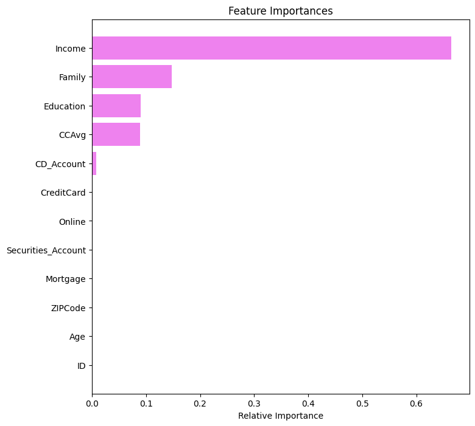

```python
feature_importance_visualize(model4, feature_names)
```

- Observations - Important features on the post pruning also income similar to the pre-pruning.

## Model Performance Comparison and Final Model Selection

```python
# training performance comparison

models_train_comp_df = pd.concat(
    [
        decision_tree_default_perf_train.T,

        decision_tree_tune_perf_train.T,
        decision_tree_post_perf_train.T,
    ],
    axis=1,
)
models_train_comp_df.columns = [
    "Decision Tree (sklearn default)",

    "Decision Tree (Pre-Pruning)",
    "Decision Tree (Post-Pruning)",
]
print("Training performance comparison:")
models_train_comp_df
```

```
Training performance comparison:
```

|  | Decision Tree (sklearn default) | Decision Tree (Pre-Pruning) | Decision Tree (Post-Pruning) |
| --- | --- | --- | --- |
| Accuracy | 1.0 | 0.790286 | 0.956857 |
| Recall | 1.0 | 1.000000 | 1.000000 |
| Precision | 1.0 | 0.310798 | 0.686722 |
| F1 | 1.0 | 0.474212 | 0.814268 |

```python
# testing performance comparison

models_test_comp_df = pd.concat(
    [

        decision_tree_perf_test.T,
        decision_tree_tune_perf_test.T,
        decision_tree_post_test.T,
    ],
    axis=1,
)
models_test_comp_df.columns = [
    "Decision Tree (sklearn default)",

    "Decision Tree (Pre-Pruning)",
    "Decision Tree (Post-Pruning)",
]
print("Test set performance comparison:")
models_test_comp_df
```

```
Test set performance comparison:
```

|  | Decision Tree (sklearn default) | Decision Tree (Pre-Pruning) | Decision Tree (Post-Pruning) |
| --- | --- | --- | --- |
| Accuracy | 0.978667 | 0.779333 | 0.948667 |
| Recall | 0.892617 | 1.000000 | 0.993289 |
| Precision | 0.892617 | 0.310417 | 0.660714 |
| F1 | 0.892617 | 0.473768 | 0.793566 |

##### the best model among the three (Default, Pre-Pruned, Post-Pruned Decision Trees) is: Post-Pruned model.

- It performs well on both training and test data, Minimal overfitting compared to the default tree.
- High recall (1.0 train, 0.993 test) — it catches almost all positives.
- Improved precision over pre-pruning (0.686 train, 0.661 test).
- Strong F1 score (0.814 train, 0.794 test) — good balance between precision and recall.
- Very high accuracy (0.957 train, 0.949 test), close to the default tree but with less overfitting.

## Actionable Insights and Business Recommendations

#### What recommedations would you suggest to the bank?

To optimize marketing efforts and improve personal loan conversions, focus on customers who meet the following criteria:

- Income: Between $110,000 and $175,000 annually.
- Age: Between 35 and 55 years.
- Professional Experience: Between 10 and 30 years.
- Education Level: Either Graduate (2) or Professional/Advanced (3).
- Financial Products: Must have both a Certificate of Deposit (CD) Account and a Securities Account.
- Family Size: Preferably 3 or 4 members.
- Credit Card Usage: Average monthly spending between $2,000 and $5,000.
- Mortgage: Must have an active mortgage (value > 0).